# Coursework Report

*N* removed NAs: 2

*N* removed <18: 29

*N* total clean: 117

| Group | *N* | *M*<sub>age</sub> | *M*<sub>rating</sub> |
| --- | --- | --- | --- |
| Control | 55 | 20.6 | 6.54 |
| Experim | 62 | 20.8 | 5.87 |

**Main analysis results**

*t*(115) = 4.69, *p* < .001

# Coursework Report

Analysing Data, Spring 2020

# Method

## Participants

Table 1 *Descriptive statistics of participants’ ages by condition*

| Group | *N* | *M*<sub>Age</sub> | *SD*<sub>Age</sub> | *Min*<sub>Age</sub> | *Max*<sub>Age</sub> |
| --- | --- | --- | --- | --- | --- |
| Red | 62 | 20.8 | 2.17 | 18 | 28 |
| White | 55 | 20.6 | 2.12 | 18 | 26 |

## Design

The aim of this study was to replicate Experiment 1 of Elliot et al (2010), which investigated the influence of colour on attractiveness. The between-subjects design was the same as that in Experiment 1 of Elliot et al (2010), testing whether women’s ratings of a male’s attractiveness depend upon whether his photo is shown with a red border or a white border. An independent-samples *t*-test was used to evaluate whether colour condition had a significant effect on the ratings of attractiveness.

Participants were randomly assigned to one of the two levels of the independent variable (colour condition). In the experimental group, the photo on which they were asked to base their ratings was printed with a red border. Participants in the control group were given the same photo except the border around the image was left white. The photo shown (a moderately attractive Caucasian man) was the same as that used in Experiment 1 of Elliot et al (2010).

To measure perceived attractiveness, the same measure as in Elliot et al (2010) was used. After being shown the bordered image for five seconds, participants were asked three questions: “How attractive do you think this person is?”, “How pleasant is this person to look at?” and “If I were to meet the person in this picture face to face, I would think he is attractive.”. They rated each item on 9-point scales which ranged from 1 to 9. These three ratings were then averaged to form a composite measure from 1 to 9 where higher scores indicated that the participant found the man more attractive.

At the end of the experiment, participants were asked to guess the purpose of the study. A correct guess was recorded if the they mentioned colour and attractiveness. Participants were debriefed before being dismissed.

# Results

Contrary to the findings of Elliot et al (2010), on average participants in the red condition rated the man as less attractive than participants in the control condition (*M*<sub>white</sub> = 6.54, *SD*<sub>white</sub> = 0.91 and *M*<sub>red</sub> = 5.87, *SD*<sub>red</sub> = 0.64). An independent-samples *t*-test was conducted to evaluate the influence of colour condition on ratings of perceived attractiveness. This revealed a significant effect of colour, *t* (115) = -4.69, *p* < .001.

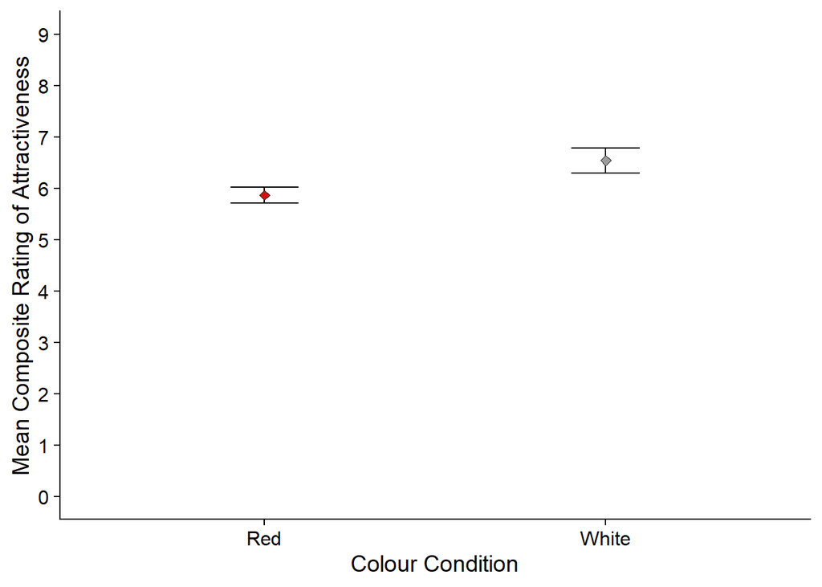

*Fig 1* Mean composite ratings of attractiveness by colour condition. Error bars represent 95% CI.

It is worth noting that the highest correlation between ratings in reply to the three questions used to form the composite measure of perceived attractiveness was *r*(115) = .16, *p* = .089.

# Discussion

In the present research, we investigated the effect of red on male attractiveness found in Elliot et al (2010). The experiment in the present research was a direct replication of Experiment 1 of Elliot et al (2010), conducted ten years earlier to investigate the effect of red on male attractiveness. The same procedure was followed, and the same materials used, with similarly aged participants. The study’s statistical power was increased by using a far larger sample size. Our results support our hypothesis that females’ perceptions of attractiveness will differ when the male target is presented in conjunction with either red or white. However, lower attractiveness ratings were given in the red condition, the opposite of the effect reported in Elliot et al (2010) despite the near identical procedure.

There has been much attention paid to this area of research, many other researchers have found a positive effect of red in the context of affiliation (Elliot & Niesta, 2008; Pazda et al., 2012; Pazda & Greitemeyer, 2015), although a close replication of Experiment 1 of Elliot et al (2010) by Hesslinger and colleagues (2015) yielded no significant results. The finding of the present replication, that red may in some instances have a negative effect on attractiveness ratings, demands a consideration of the complexities of the effect of colour on perception.

Colour-in-context theory (Elliott and Maier 2012) has provided a framework for exploring how colours can have different effects depending on the situation in which they are presented (based on biological and socially learnt associations). Red’s positive influence on perceptions of attractiveness for both male and female targets has been shown to be mediated by status and sexual receptivity respectively (Elliot et al., 2010; Elliot & Niesta, 2008; Pazda et al., 2012). However, perceptions of dominance and aggression can be increased by the presence of red (Elliot et al., 2007; Feltman & Elliot, 2011; Hill & Barton, 2005), and in achievement-related contexts those wearing red are perceived as less able and intelligent. These factors can all play a role in how attractiveness is perceived, and so there is the possibility that they may compete with each other: in the presence of red, increased perceived aggression may counteract increased perceived status (Geniole & McCormick, 2013). Because our experiment was designed as a direct replication of Experiment 1 in Elliot et al (2010), we cannot draw conclusions about whether perceived status played a role, as per the findings of the original study as a whole (Elliot et al., 2010). To understand why the red and white conditions may have affected attractiveness ratings in a way different to that in the original experiment, more information about perceptions that contribute towards perceived attractiveness is needed. Does status always play a role in mediation, and is red’s influence on status reliable? Do perceptions of aggressiveness or intelligence come into play, and are the factors involved more important or less so today than they were ten years ago, or do they associate with colour in a new way? Future research considering the interplay of these perceptions could help to make sense of the mixed findings across this domain. Given the suggested context-specific nature of the red effect, it could be useful to try to understand the frame of mind of participants. Understanding what attributes are most salient when attractiveness judgements are made would provide more detail to the puzzle.

White was used in the control condition for many of the cited studies. Whilst this provided a neutral contrast to the red condition, it is important not to overlook any effect that white might have in a situation. Cross-culturally, white holds diverse associations, from symbolising naive innocence to displaying sombre mourning. Using white as a control also means that observed effects could be caused by the mere presence of colour, rather than one colour in particular. Conducting further experiments using a range of colours as comparisons, as well as white, would provide a richer picture of the effect of colour on perceptions and might point to causes of the difference between Elliot’s and our results.

Interpersonal attraction is complex; by using a static image Elliot designed a well controlled experiment, but it is far removed from everyday life. Using a range of male targets in static images or even using videos or in-person interactions in future experiments would provide more ecologically valid results, but may present control challenges.

By artificially introducing red to the photograph of the male instead of showing him in differently coloured clothes, we removed any possibility that attractiveness ratings were influenced by his choice of colour, or that the colour affected the way he posed or smiled. Controlling these variables allowed us to draw more reliable conclusions about the cause of any differences in conditions, but it limits how these results can be generalised to real life situations. Attractiveness ratings are just one small factor impacting behaviour: more naturalistic experiments would need to be designed to determine how changes in perceptions of attractiveness due to colour condition translate into changes in behaviour. As participants were given little guidance on the context in which they were basing their decisions and given the differences associated with long term and short-term mate preferences, it could be beneficial to clarify within the experiment the meaning of ‘attractive’ to participants (Buss & Schmitt, 2019). Societal changes in the intervening period may have an impact here.

As the aim of our study was to produce a direct replication, we were restricted to using the same measure of attractiveness. Whilst Elliot et al (2010) reported high internal consistency in the composite score of attractiveness, none of our items correlated strongly with each other, which may indicate that attractiveness was not effectively operationalised. The source of this difference is not clear: it could be down to a social or linguistic change in the ten years since the first study was published, or because our sample consisted of participants with different cultural attitudes. However, it highlights an important area to investigate before designing more studies that rely on this measure. It may also indicate that accurate replication of an experiment in a changed society is fundamentally challenging.

This study further complicates the picture of how red affects perceptions of attractiveness and highlights some exciting areas for future research. Understanding the effect of colour in different contexts, how these contexts might overlap or compete and the factors affecting different individuals’ interpretation of context is necessary as the research exploring the impact of colour continues to expand.

# References

Buss, D. M., & Schmitt, D. P. (2019). Mate preferences and their behavioural manifestations. *Annual Review of Psychology, 70*(1), 77–110. https://doi.org/10.1146/annurev-psych-010418-103408

Elliot, A. J., Maier, M. A., Moller, A. C., Friedman, R., & Meinhardt, J. (2007). Color and psychological functioning: The effect of red on performance attainment. *Journal of Experimental Psychology: General, 136*(1), 154–168. https://doi.org/10.1037/0096-3445.136.1.154

Elliot, A. J., & Niesta, D. (2008). Romantic red: Red enhances men’s attraction to women. *Journal of Personality and Social Psychology, 95*(5), 1150–1164. https://doi.org/10.1037/0022-3514.95.5.1150

Elliot, A. J., Niesta Kayser, D., Greitemeyer, T., Lichtenfeld, S., Gramzow, R. H., Maier, M. A., & Liu, H. (2010). Red, rank, and romance in women viewing men. *Journal of Experimental Psychology: General, 139*(3), 399–417. https://doi.org/10.1037/a0019689

Feltman, R., & Elliot, A. J. (2011). The influence of red on perceptions of relative dominance and threat in a competitive context. *Journal of Sport and Exercise Psychology, 33*(2), 308–314. https://doi.org/10.1123/jsep.33.2.308

Geniole, S. N., & McCormick, C. M. (2013). Taking control of aggression: Perceptions of aggression suppress the link between perceptions of facial masculinity and attractiveness. *Evolutionary Psychology, 11*(5), 1027–1043. https://doi.org/10.1177/147470491301100507

Hesslinger, V. M., Goldbach, L., & Carbon, C.-C. (2015). Men in red: A reexamination of the red-attractiveness effect. *Psychonomic Bulletin Review, 22*(4), 1142–1148. https://doi.org/10.3758/s13423-015-0866-8

Hill, R. A., & Barton, R. A. (2005). Psychology: Red enhances human performance in contests. *Nature, 435*(7040), 293. https://doi.org/10.1038/435293a

Pazda, A. D., Elliot, A. J., & Greitemeyer, T. (2012). Sexy red: Perceived sexual receptivity mediates the red-attraction relation in men viewing woman. *Journal of Experimental Social Psychology, 48*(3), 787–790. https://doi.org/10.1016/j.jesp.2011.12.009

Pazda, A. D., & Greitemeyer, T. (2015). Color in romantic contexts in humans. In A. J. Elliot, M. D. Fairchild, & A. Franklin (Eds.), *Cambridge handbooks in psychology.* Handbook of color psychology (pp. 531–545). Cambridge University Press. https://doi.org/doi:10.1017/CBO9781107337930.026